# Mendelian Randomization Analysis: Alzheimer's Disease and HDL Cholesterol

By Dr. Shea Andrews, generated on 2018-09-09

```
## [1] FALSE
```

## Data sources

*HDL Cholesterol* [Willer et al Nat Genet 2013](https://www.nature.com/articles/ng.2797): To identify new loci and refine known loci influencing these lipids, we examined 188,577 individuals using genome-wide and custom genotyping arrays. We identify and annotate 157 loci associated with lipid levels at P < 5 × 10−8, including 62 loci not previously associated with lipid levels in humans.

*Late Onset Alzheimer’s disease* (LOAD, Lambert et al 2013): The International Genomics of Alzheimer’s Project (IGAP) is a meta-analysis of 4 previously published GWAS datasets: the European Alzheimer’s Disease Imitative (EADI), the Alzheimer Disease Genetics Consortium (ADGC), Cohorts for Heart and Aging Research in Genomic Epidemiology (CHARGE), and Genetic and Environmental Risk in AD (GERAD) and includes a sample of 17,008 LOAD cases and 37,154 cognitively normal elder controls. Participants in IGAP were of European ancestry, the average age was 71 and 58.4% of participants were women.

*Alzheimer’s Age of Onset Surivial* (AAOS, Huang et al 2017): A GWAS of age of onset in LOAD was conducted in 14,406 AD case samples and 25,849 control samples from the IGAP using Cox proportional hazard regressions. Participants were of European ancestry, in cases the the average AAO was 74.8 and 61.7% were women, in controls the average AAE was 79.0 and 59.6% were women.

*Hippocampal Volume* [Hibar et al 2017](https://doi.org/10.1038/ncomms13624): A GWAS of hippocampal volume perfomed in 26,814 (ENIGMA and CHARGE consortiums) individules of European Ancestry discovered 9 independent loci.

## Instrumental Vaibles

**LD Clumping:** For standard two sample MR it is important to ensure that the instruments for the exposure are independent. LD clumping can be performed using the data_clump function from the TwoSampleMR package, which uses EUR samples from the 1000 genomes project to estimate LD between SNPs and amonst SNPs that have and LD above a given threshold, only the SNP with the lowest p-value will be retained.

### LOAD

LOAD: 1090 SNPs were associated with LOAD at p < 5e-8, with 43 SNPs remaining after LD clumping (Table 1).

**Table 1:** SNPS associated with LOAD

| SNP | CHR | POS | Effect_allele | Non_Effect_allele | EAF | Beta | SE | P | r2 | N |
| --- | --- | --- | --- | --- | --- | --- | --- | --- | --- | --- |
| rs1752684 | 1 | 207747296 | A | G | 0.1987 | 0.1541 | 0.0196 | 3.653e-15 | 0.007561854 | 54162 |
| rs4663105 | 2 | 127891427 | C | A | 0.5664 | 0.1837 | 0.0172 | 1.001e-26 | 0.016575278 | 54162 |
| rs745717 | 2 | 127893897 | C | G | 0.0992 | 0.2008 | 0.0288 | 2.879e-12 | 0.007206053 | 54162 |
| rs9272561 | 6 | 32607141 | A | G | 0.6281 | -0.1360 | 0.0230 | 3.376e-09 | 0.008640976 | 54162 |
| rs9381563 | 6 | 47432637 | C | T | 0.6211 | 0.0968 | 0.0166 | 5.300e-09 | 0.004410287 | 54162 |
| rs10808026 | 7 | 143099133 | A | C | 0.1883 | -0.1393 | 0.0206 | 1.417e-11 | 0.005931685 | 54162 |
| rs12540656 | 7 | 143117919 | G | A | 0.5360 | 0.0984 | 0.0173 | 1.169e-08 | 0.004816183 | 54162 |
| rs28834970 | 8 | 27195121 | C | T | 0.6357 | 0.0959 | 0.0162 | 3.273e-09 | 0.004259696 | 54162 |
| rs7982 | 8 | 27462481 | A | G | 0.3705 | -0.1400 | 0.0165 | 2.477e-17 | 0.009142606 | 54162 |
| rs72924659 | 11 | 60103385 | T | C | 0.3148 | -0.1413 | 0.0196 | 5.354e-13 | 0.008613237 | 54162 |

[output cut: 33 more lines]

**Table 2:** SNPS associated with HDL Cholesterol avalible in LOAD GWAS

| SNP | CHR | POS | Effect_allele | Non_Effect_allele | EAF | Beta | SE | P | r2 | N |
| --- | --- | --- | --- | --- | --- | --- | --- | --- | --- | --- |
| rs1752684 | 1 | 207784968 | A | G | 0.19920 | 0.0093 | 0.0060 | 1.238e-01 | 2.759366e-05 | NA |
| rs9381563 | 6 | 47432637 | T | C | 0.66890 | 0.0022 | 0.0051 | 8.452e-01 | 2.143857e-06 | 94311.00 |
| rs10808026 | 7 | 143109139 | C | A | 0.77180 | 0.0046 | 0.0065 | 3.277e-01 | 7.453600e-06 | NA |
| rs12540656 | 7 | 143122457 | G | A | 0.46440 | 0.0082 | 0.0051 | 2.964e-01 | 3.344957e-05 | NA |
| rs28834970 | 8 | 27211910 | T | C | 0.64640 | 0.0047 | 0.0049 | 3.920e-01 | 1.009809e-05 | NA |
| rs7982 | 8 | 27464519 | A | C,G | 0.39450 | 0.0041 | 0.0054 | 5.685e-01 | 8.030801e-06 | NA |
| rs10792832 | 11 | 85867875 | A | G | 0.38260 | 0.0014 | 0.0049 | 9.413e-01 | 9.259716e-07 | 94311.00 |
| rs11218343 | 11 | 121435587 | C | T | 0.03958 | 0.0273 | 0.0163 | 1.326e-01 | 5.666205e-05 | 86279.00 |
| rs8093731 | 18 | 29088958 | T | C | 0.01319 | 0.0737 | 0.0295 | 4.354e-02 | 1.413980e-04 | 60603.00 |
| rs4147929 | 19 | 1056492 | A | G | 1.00000 | 0.0040 | 0.0084 | 8.410e-01 | 0.000000e+00 | NA |

[output cut: 13 more lines]

### AAOS

AAOS: 311 SNPs were associated with AAOS at p < 5e-8, with 20 SNPs remaining after LD clumping (Table 3).

**Table 3:** SNPS associated with AAOS

| SNP | CHR | POS | Effect_allele | Non_Effect_allele | EAF | Beta | SE | P | r2 | N |
| --- | --- | --- | --- | --- | --- | --- | --- | --- | --- | --- |
| rs6431219 | 2 | 127862133 | T | C | 0.4163 | 0.0774 | 0.0124 | 3.897e-10 | 0.002911441 | 40255 |
| rs13032148 | 2 | 127865100 | A | G | 0.3293 | 0.0820 | 0.0144 | 1.125e-08 | 0.002970146 | 40255 |
| rs7930318 | 11 | 60033371 | T | C | 0.5996 | 0.0750 | 0.0125 | 2.245e-09 | 0.002700898 | 40255 |
| rs567075 | 11 | 85830157 | T | C | 0.3097 | -0.0900 | 0.0132 | 9.084e-12 | 0.003463332 | 40255 |
| rs2301274 | 19 | 45146402 | T | C | 0.7677 | 0.0899 | 0.0147 | 9.572e-10 | 0.002882638 | 40255 |
| rs2965101 | 19 | 45237812 | T | C | 0.6815 | 0.1075 | 0.0135 | 1.432e-15 | 0.005016747 | 40255 |
| rs8103315 | 19 | 45254168 | A | C | 0.1479 | 0.1652 | 0.0262 | 3.074e-10 | 0.006878739 | 40255 |
| rs28399657 | 19 | 45318351 | A | G | 0.9772 | 0.3195 | 0.0574 | 2.603e-08 | 0.004548729 | 40255 |
| rs28399664 | 19 | 45324756 | C | G | 0.9593 | -0.7349 | 0.0805 | 6.888e-20 | 0.042173082 | 40255 |
| rs10412413 | 19 | 45327309 | T | C | 0.3551 | 0.1896 | 0.0125 | 8.083e-52 | 0.016464544 | 40255 |

[output cut: 10 more lines]

**Table 4:** SNPS associated with HDL Cholesterol avalible in AAOS GWAS

| SNP | CHR | POS | Effect_allele | Non_Effect_allele | EAF | Beta | SE | P | r2 | N |
| --- | --- | --- | --- | --- | --- | --- | --- | --- | --- | --- |
| rs7930318 | 11 | 60030457 | C | T | 0.41030 | 0.0064 | 0.0049 | 1.534e-01 | 1.982086e-05 | NA |
| rs567075 | 11 | 85830157 | T | C | 0.33510 | 0.0002 | 0.0050 | 7.740e-01 | 1.782464e-08 | 94311.00 |
| rs2301274 | 19 | 45146103 | C | T | 0.26390 | 0.0155 | 0.0059 | 3.060e-02 | 9.334039e-05 | NA |
| rs2965101 | 19 | 45237812 | C | T | 0.34700 | 0.0130 | 0.0037 | 5.482e-04 | 7.658776e-05 | 184801.00 |
| rs8103315 | 19 | 45254168 | C | A | 0.86410 | 0.0117 | 0.0053 | 5.092e-02 | 3.215031e-05 | 156397.04 |
| rs10412413 | 19 | 45329214 | C | T | 0.65960 | 0.0205 | 0.0035 | 6.148e-09 | 1.887156e-04 | NA |
| rs12610605 | 19 | 45370838 | G | A | 0.85490 | 0.0096 | 0.0045 | 1.140e-01 | 2.286416e-05 | 183834.94 |
| rs11665676 | 19 | 45379791 | T | C | 0.06069 | 0.0110 | 0.0069 | 2.183e-01 | 1.379563e-05 | NA |
| rs2075650 | 19 | 45395619 | A | G | 0.87340 | 0.0554 | 0.0051 | 9.716e-26 | 6.787290e-04 | 175421.02 |
| rs77301115 | 19 | 45396973 | G | A | 0.97361 | 0.0972 | 0.0157 | 1.032e-08 | 4.854974e-04 | 86278.66 |

[output cut: 4 more lines]

### Hippocampul volume

hipv: 421 SNPs were associated with hipv at p < 5e-8, with 9 SNPs remaining after LD clumping (Table 1).

**Table 1:** SNPS associated with hipv

| SNP | CHR | POS | Effect_allele | Non_Effect_allele | EAF | Zscore | Beta | SE | P | r2 | N |
| --- | --- | --- | --- | --- | --- | --- | --- | --- | --- | --- | --- |
| rs2268894 | 2 | 162856148 | T | C | 0.5412 | -6.546 | -0.05668170 | 0.008658983 | 5.894e-11 | 0.001595500 | 26814 |
| rs11979341 | 7 | 155797978 | C | G | 0.6837 | -6.755 | -0.06558167 | 0.009708611 | 1.424e-11 | 0.001860200 | 24484 |
| rs7976802 | 12 | 65828547 | A | T | 0.3781 | 6.359 | 0.05658511 | 0.008898429 | 2.028e-10 | 0.001505780 | 26814 |
| rs61921502 | 12 | 65832468 | T | G | 0.8466 | 9.017 | 0.10788399 | 0.011964511 | 1.941e-19 | 0.003023066 | 26814 |
| rs17177768 | 12 | 65552794 | T | C | 0.2504 | -7.702 | -0.07668244 | 0.009956172 | 1.339e-14 | 0.002207424 | 26814 |
| rs77956314 | 12 | 117323367 | T | C | 0.9160 | -10.418 | -0.16185421 | 0.015536016 | 2.055e-25 | 0.004031371 | 26814 |
| rs2289881 | 5 | 66084260 | T | G | 0.3544 | -5.558 | -0.05014690 | 0.009022472 | 2.728e-08 | 0.001150735 | 26814 |
| rs7020341 | 9 | 119247974 | C | G | 0.3590 | 6.645 | 0.05989482 | 0.009013518 | 3.035e-11 | 0.001651053 | 26700 |
| rs117753030 | 12 | 65248748 | A | G | 0.9223 | 5.484 | 0.08928274 | 0.016280588 | 4.170e-08 | 0.001142505 | 26293 |

**Table 2:** SNPS associated with HDL Cholesterol avalible in hipv GWAS

| SNP | CHR | POS | Effect_allele | Non_Effect_allele | EAF | Beta | SE | P | r2 | N |
| --- | --- | --- | --- | --- | --- | --- | --- | --- | --- | --- |
| rs2268894 | 2 | 162856148 | C | T | 0.44590 | 0.0000 | 0.0048 | 0.86220 | 0.000000e+00 | 94311 |
| rs2289881 | 5 | 66084260 | G | T | 0.64640 | 0.0027 | 0.0050 | 0.74860 | 3.332507e-06 | 94311 |
| rs7020341 | 9 | 119247974 | G | C | 1.00000 | 0.0054 | 0.0050 | 0.17090 | 0.000000e+00 | 94306 |
| rs17177768 | 12 | 65552794 | C | T | 0.75990 | 0.0093 | 0.0054 | 0.08631 | 3.156055e-05 | 94311 |
| rs7976802 | 12 | 65824224 | A | T | 0.36280 | 0.0087 | 0.0052 | 0.12150 | 3.499545e-05 | NA |
| rs77956314 | 12 | 117327592 | T | C | 0.91821 | 0.0021 | 0.0086 | 0.54280 | 6.623855e-07 | NA |

## Data harmonization

Harmonize the exposure and outcome datasets so that the effect of a SNP on the exposure and the effect of that SNP on the outcome correspond to the same allele. The harmonise_data function from the TwoSampleMR package can be used to perform the harmonization step, by default it try’s to infer the forward strand alleles using allele frequency information. EAF were not availbe in the IGAP summary statisitics, as such the allele frequencies reported in the AAOS anaylsis were used.

### LOAD ~ HDL Cholesterol

**Table 11:** Harmonized HDL Cholesterol and LOAD datasets

| SNP | effect_allele.exposure | other_allele.exposure | effect_allele.outcome | other_allele.outcome | beta.exposure | beta.outcome | eaf.exposure | eaf.outcome | se.outcome | pval.outcome | se.exposure | pval.exposure |
| --- | --- | --- | --- | --- | --- | --- | --- | --- | --- | --- | --- | --- |
| rs10792832 | A | G | A | G | -0.1297 | 0.0014 | 0.3563 | 0.38260 | 0.0049 | 9.413e-01 | 0.0161 | 6.534e-16 |
| rs10808026 | A | C | A | C | -0.1393 | -0.0046 | 0.1883 | 0.22820 | 0.0065 | 3.277e-01 | 0.0206 | 1.417e-11 |
| rs11218343 | C | T | C | T | -0.2697 | 0.0273 | 0.9605 | 0.03958 | 0.0163 | 1.326e-01 | 0.0410 | 4.976e-11 |
| rs113321260 | A | G | A | G | 0.2726 | 0.0070 | 0.0972 | 0.10290 | 0.0054 | 2.261e-01 | 0.0286 | 1.349e-21 |
| rs1160984 | T | C | T | C | -0.3398 | 0.0254 | 0.0581 | 0.06069 | 0.0111 | 5.359e-02 | 0.0414 | 2.260e-16 |
| rs11673139 | T | A | T | A | -0.4111 | 0.0137 | 0.9190 | NA | 0.0096 | 1.499e-01 | 0.0402 | 1.635e-24 |
| rs12540656 | G | A | G | A | 0.0984 | 0.0082 | 0.5360 | 0.46440 | 0.0051 | 2.964e-01 | 0.0173 | 1.169e-08 |
| rs12972156 | G | C | G | C | 1.1399 | 0.0554 | 0.8125 | 0.87340 | 0.0051 | 9.716e-26 | 0.0256 | 1.000e-200 |
| rs1752684 | A | G | A | G | 0.1541 | 0.0093 | 0.1987 | 0.19920 | 0.0060 | 1.238e-01 | 0.0196 | 3.653e-15 |
| rs28834970 | C | T | C | T | 0.0959 | -0.0047 | 0.6357 | 0.35360 | 0.0049 | 3.920e-01 | 0.0162 | 3.273e-09 |

[output cut: 13 more lines]

### AAOS ~ HDL Cholesterol

**Table 12:** Harmonized HDL Cholesterol and AAOS datasets

| SNP | effect_allele.exposure | other_allele.exposure | effect_allele.outcome | other_allele.outcome | beta.exposure | beta.outcome | eaf.exposure | eaf.outcome | se.outcome | pval.outcome | se.exposure | pval.exposure |
| --- | --- | --- | --- | --- | --- | --- | --- | --- | --- | --- | --- | --- |
| rs10412413 | T | C | T | C | 0.1896 | -0.0205 | 0.3551 | 0.34040 | 0.0035 | 6.148e-09 | 0.0125 | 8.083e-52 |
| rs11665676 | T | C | T | C | -0.2168 | 0.0110 | 0.0456 | 0.06069 | 0.0069 | 2.183e-01 | 0.0323 | 2.049e-11 |
| rs12610605 | A | G | A | G | -0.1229 | -0.0096 | 0.1600 | 0.14510 | 0.0045 | 1.140e-01 | 0.0171 | 6.842e-13 |
| rs157595 | A | G | A | G | -0.2787 | 0.0273 | 0.3711 | 0.37990 | 0.0040 | 2.328e-10 | 0.0308 | 1.304e-19 |
| rs16979586 | A | G | A | G | -0.2032 | -0.0280 | 0.9504 | 0.95383 | 0.0102 | 3.228e-02 | 0.0268 | 3.396e-14 |
| rs2004357 | A | G | A | G | 0.1825 | 0.0046 | 0.0921 | 0.10550 | 0.0081 | 4.639e-01 | 0.0222 | 1.795e-16 |
| rs2075650 | A | G | A | G | -0.5502 | 0.0554 | 0.7803 | 0.87340 | 0.0051 | 9.716e-26 | 0.0223 | 5.980e-134 |
| rs2301274 | T | C | T | C | 0.0899 | -0.0155 | 0.7677 | 0.73610 | 0.0059 | 3.060e-02 | 0.0147 | 9.572e-10 |
| rs2965101 | T | C | T | C | 0.1075 | -0.0130 | 0.6815 | 0.65300 | 0.0037 | 5.482e-04 | 0.0135 | 1.432e-15 |
| rs567075 | T | C | T | C | -0.0900 | 0.0002 | 0.3097 | 0.33510 | 0.0050 | 7.740e-01 | 0.0132 | 9.084e-12 |

[output cut: 4 more lines]

### Hippcampul Volume ~ HDL Cholesterol

**Table 11:** Harmonized HDL Cholesterol and HV datasets

| SNP | effect_allele.exposure | other_allele.exposure | effect_allele.outcome | other_allele.outcome | beta.exposure | beta.outcome | eaf.exposure | eaf.outcome | se.outcome | pval.outcome | se.exposure | pval.exposure |
| --- | --- | --- | --- | --- | --- | --- | --- | --- | --- | --- | --- | --- |
| rs17177768 | T | C | T | C | -0.07668244 | -0.0093 | 0.2504 | 0.24010 | 0.0054 | 0.08631 | 0.009956172 | 1.339e-14 |
| rs2268894 | T | C | T | C | -0.05668170 | 0.0000 | 0.5412 | 0.55410 | 0.0048 | 0.86220 | 0.008658983 | 5.894e-11 |
| rs2289881 | T | G | T | G | -0.05014690 | -0.0027 | 0.3544 | 0.35360 | 0.0050 | 0.74860 | 0.009022472 | 2.728e-08 |
| rs7020341 | C | G | C | G | 0.05989482 | -0.0054 | 0.3590 | NA | 0.0050 | 0.17090 | 0.009013518 | 3.035e-11 |
| rs77956314 | T | C | T | C | -0.16185421 | 0.0021 | 0.9160 | 0.91821 | 0.0086 | 0.54280 | 0.015536016 | 2.055e-25 |
| rs7976802 | A | T | A | T | 0.05658511 | 0.0087 | 0.3781 | 0.36280 | 0.0052 | 0.12150 | 0.008898429 | 2.028e-10 |

## Pleiotropy

Pleiotropy was assesed using Mendelian Randomization Pleiotropy RESidual Sum and Outlier (MR-PRESSO), that allows for the evlation of evaluation of horizontal pleiotropy in a standared MR model. MR-PRESSO performs a global test for detection of horizontal pleiotropy and correction of pleiotropy via outlier removal.

**LOAD ~ HDL Cholesterol:** The MR-PRESSO global test for pleiotropy was significant (p = <0.001). The following SNPs were removed due to pleiotropy: rs12972156, rs2927477, rs35336243, rs4803763, rs760136, rs77301115

**AAOS ~ HDL Cholesterol:** The MR-PRESSO global test for pleiotropy was significant (p = <0.001). The following SNPs were removed due to pleiotropy: rs12610605, rs16979586, rs8111069

**HV ~ HDL Cholesterol:** The MR-PRESSO global test for pleiotropy was non-significant.

## Mendelian Randomization Analysis

### LOAD ~ HDL Cholesterol

Figure 1 illustrates the SNP-specific associations with HDL Cholesterol versus the association between each SNP and risk of LOAD.

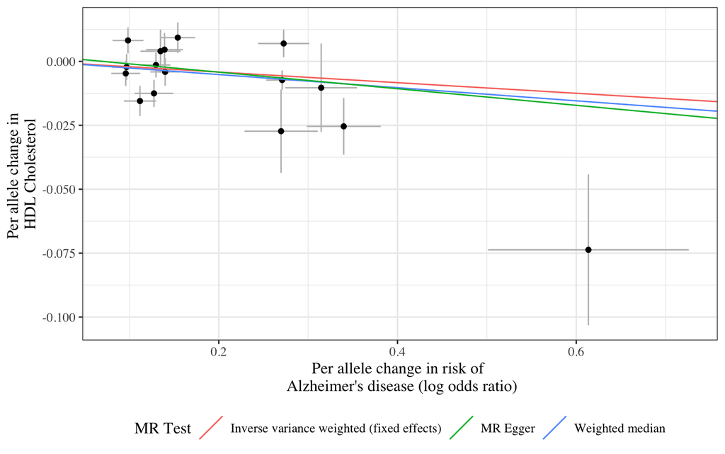

Fig. 1: Scatterplot of SNP effects for the association of Trait and LOAD

Figure 2 and Table 1 shows the SNP-specific effects and overall IVW, weighted median and Egger regression causal estimates of genetically predicted risk of LOAD on HDL Cholesterol.

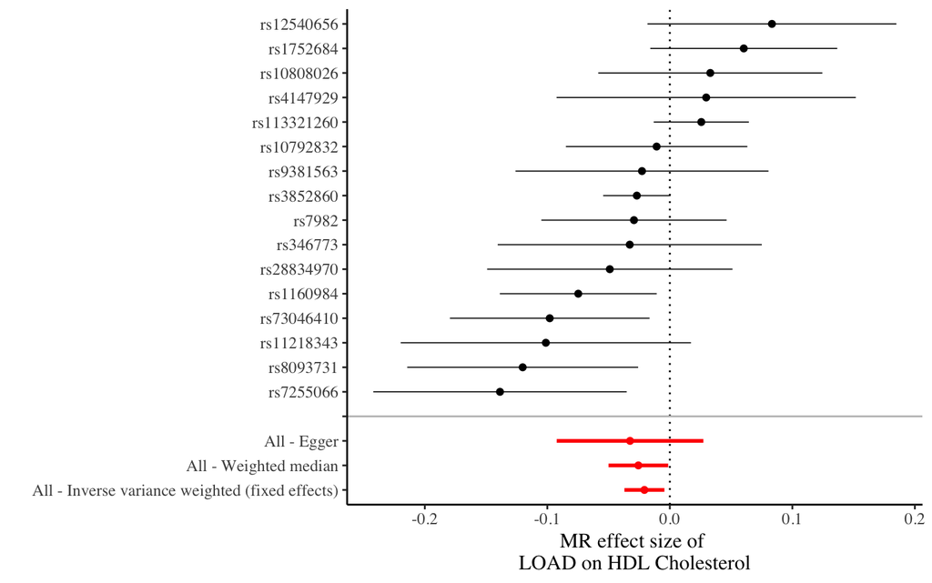

Fig. 2: Forrest plot of Wald ratios and 95% CIs for SNP-specific and overall IVW, Weighted median and Egger associations

**Table 1:** MR estimates for LOAD on HDL Cholesterol

|  | SNP | b | se | p |
| --- | --- | --- | --- | --- |
| 1 | rs10792832 | -0.01079414 | 0.03777949 | 0.77509696 |
| 2 | rs10808026 | 0.03302225 | 0.04666188 | 0.47913636 |
| 3 | rs11218343 | -0.10122358 | 0.06043752 | 0.09396433 |
| 4 | rs113321260 | 0.02567865 | 0.01980924 | 0.19487342 |
| 5 | rs1160984 | -0.07474985 | 0.03266627 | 0.02212074 |
| 6 | rs12540656 | 0.08333333 | 0.05182927 | 0.10786954 |
| 7 | rs1752684 | 0.06035042 | 0.03893576 | 0.12114152 |
| 8 | rs28834970 | -0.04900938 | 0.05109489 | 0.33746622 |
| 9 | rs346773 | -0.03273999 | 0.05499046 | 0.55159235 |
| 10 | rs3852860 | -0.02694721 | 0.01402732 | 0.05472507 |

[output cut: 9 more lines]

Figure 3 shows a funnel plot to detect pleiotropy and Table 2 show the results of Cochrans Q heterogeneity test to assess for the presence of pleiotropy.

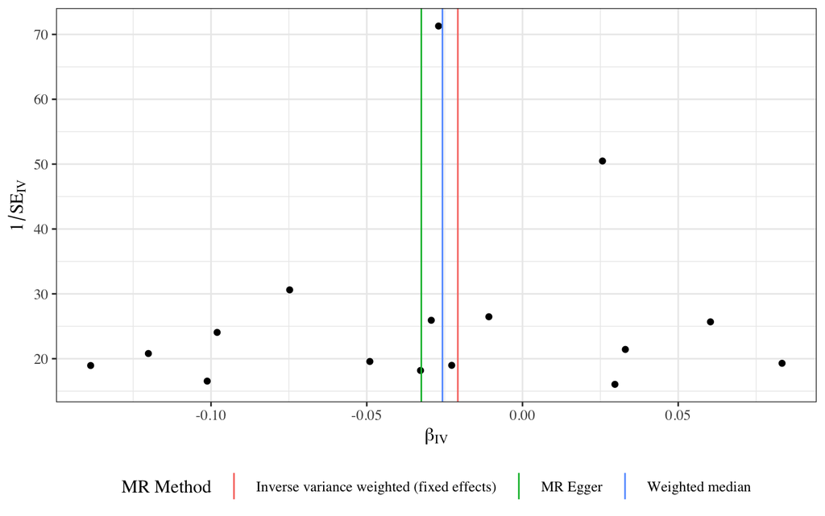

Fig. 3: Funnel plot of the Trait – LOAD causal estimates against their precession

**Table 2:** Heterogenity tests for HDL Cholesterol and LOAD

| exposure | outcome | method | Q | Q_df | Q_pval |
| --- | --- | --- | --- | --- | --- |
| LOAD | hdl | MR Egger | 33.31414 | 14 | 0.002595087 |
| LOAD | hdl | Inverse variance weighted | 33.74032 | 15 | 0.003703007 |

**Table 3:** Test for directional pleitropy for LOAD and HDL Cholesterol

| id.exposure | id.outcome | outcome | exposure | egger_intercept | se | pval |
| --- | --- | --- | --- | --- | --- | --- |
| I4FETd | TFdAz4 | hdl | LOAD | 0.002326704 | 0.005497896 | 0.678579 |

### AAOS ~ HDL Cholesterol

Figure 4 illustrates the SNP-specific associations with AAOS versus the association between each SNP and HDL Cholesterol.

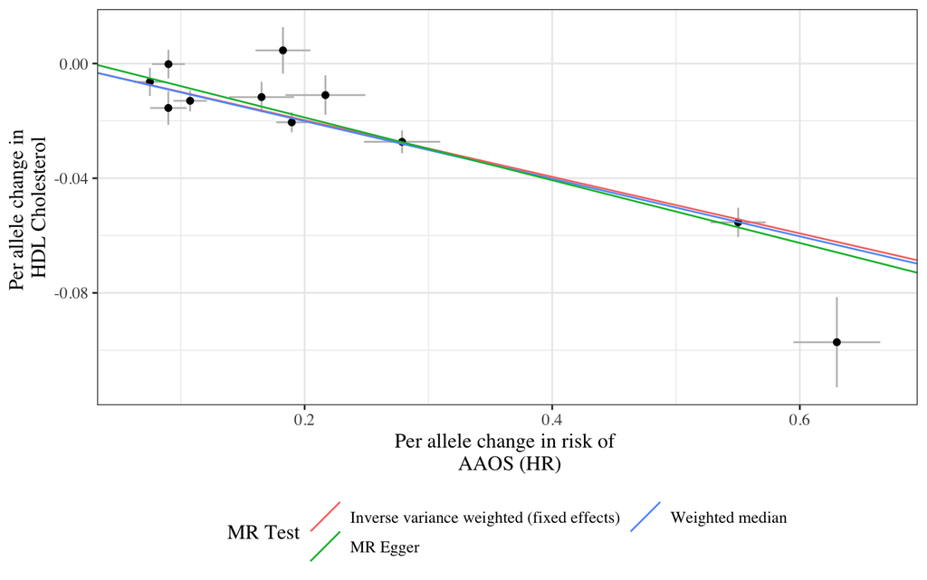

Fig. 4: Scatterplot of SNP effects for the association of Trait and AAOS

Figure 5 and Table 4 shows the SNP-specific effects and overall IVW, weighted median and Egger regression causal estimates of genetically predicted AAOS on HDL Cholesterol.

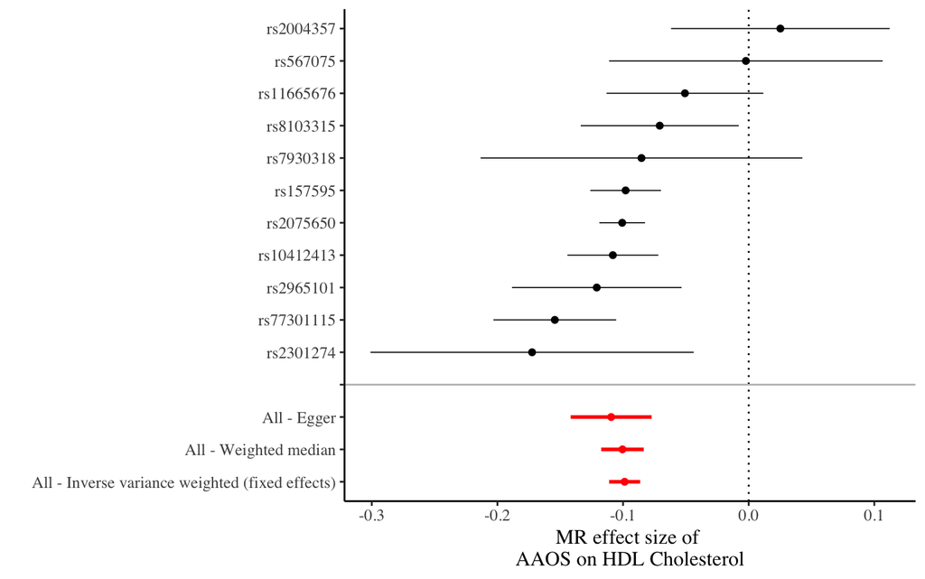

Fig. 5: Forrest plot of Wald ratios and 95% CIs for SNP-specific and overall IVW, Weighted median and Egger associations

**Table 4:** MR estimates for AAOS and HDL Cholesterol

|  | SNP | b | se | p |
| --- | --- | --- | --- | --- |
| 1 | rs10412413 | -0.108122363 | 0.018459916 | 4.708980e-09 |
| 2 | rs11665676 | -0.050738007 | 0.031826568 | 1.108906e-01 |
| 3 | rs157595 | -0.097954790 | 0.014352350 | 8.792532e-12 |
| 4 | rs2004357 | 0.025205479 | 0.044383562 | 5.701020e-01 |
| 5 | rs2075650 | -0.100690658 | 0.009269357 | 1.734552e-27 |
| 6 | rs2301274 | -0.172413793 | 0.065628476 | 8.611130e-03 |
| 7 | rs2965101 | -0.120930233 | 0.034418605 | 4.422219e-04 |
| 8 | rs567075 | -0.002222222 | 0.055555556 | 9.680931e-01 |
| 9 | rs77301115 | -0.154310208 | 0.024924591 | 5.975231e-10 |
| 10 | rs7930318 | -0.085333333 | 0.065333333 | 1.915109e-01 |

[output cut: 4 more lines]

Figure 6 shows a funnel plot to detect pleiotropy and Table 5 show the results of Cochrans Q heterogeneity test to assess for the presence of pleiotropy.

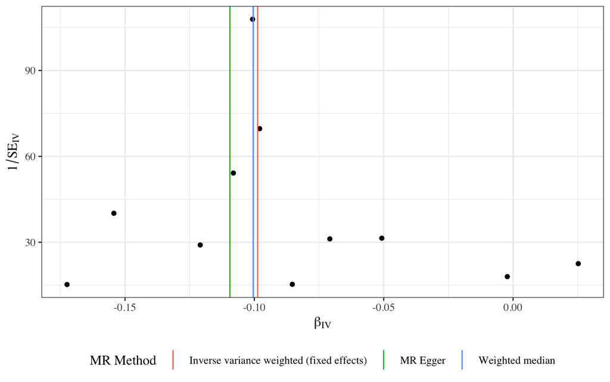

**Table 5:** Heterogenity tests for AAOS and HDL Cholesterol

| exposure | outcome | method | Q | Q_df | Q_pval |
| --- | --- | --- | --- | --- | --- |
| AAOS | hdl | MR Egger | 19.48780 | 9 | 0.02135028 |
| AAOS | hdl | Inverse variance weighted | 20.84324 | 10 | 0.02221358 |

**Table 6:** Test for directional pleitropy for AAOS and HDL Cholesterol

| id.exposure | id.outcome | outcome | exposure | egger_intercept | se | pval |
| --- | --- | --- | --- | --- | --- | --- |
| jsoVLl | uXwYfB | hdl | AAOS | 0.00310105 | 0.00391949 | 0.449182 |

### HV ~ HDL Cholesterol

Figure 4 illustrates the SNP-specific associations with hipv versus the association between each SNP and HDL Cholesterol.

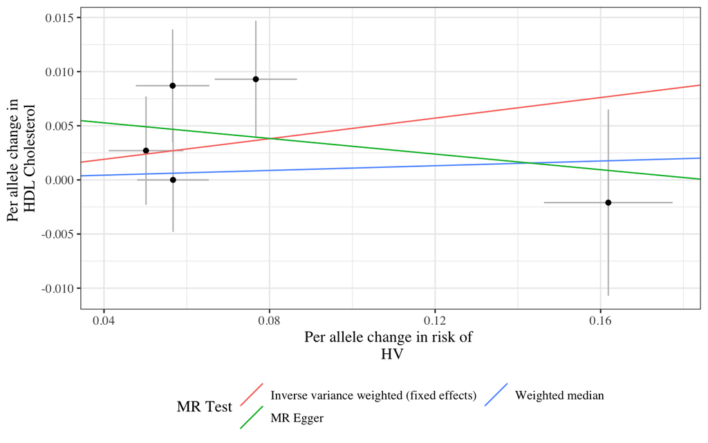

Fig. 4: Scatterplot of SNP effects for the association of Trait and hipv

Figure 5 and Table 4 shows the SNP-specific effects and overall IVW, weighted median and Egger regression causal estimates of genetically predicted HV on HDL Cholesterol.

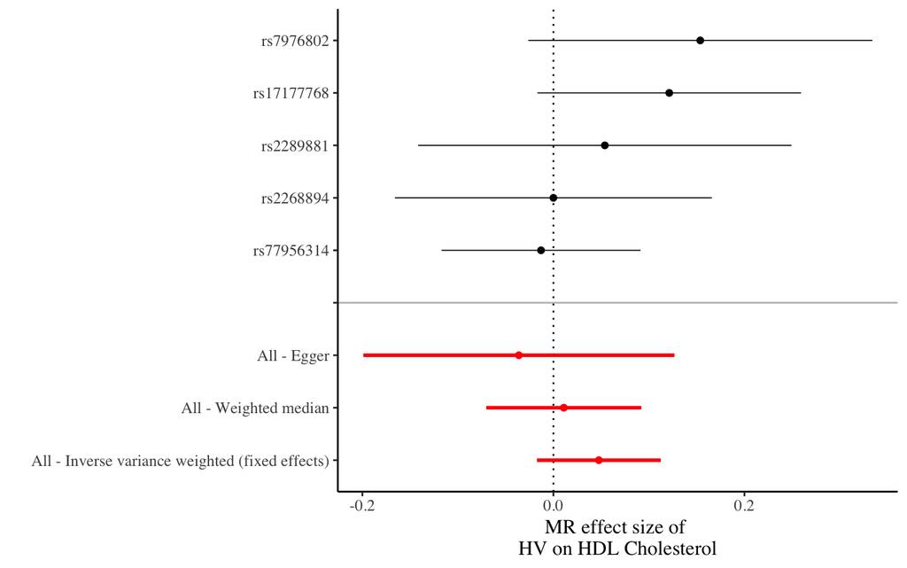

Fig. 5: Forrest plot of Wald ratios and 95% CIs for SNP-specific and overall IVW, Weighted median and Egger associations

**Table 4:** MR estimates for HV and HDL Cholesterol

|  | SNP | b | se | p |
| --- | --- | --- | --- | --- |
| 1 | rs17177768 | 0.12127940 | 0.07042030 | 0.08502927 |
| 2 | rs2268894 | 0.00000000 | 0.08468342 | 1.00000000 |
| 3 | rs2289881 | 0.05384181 | 0.09970706 | 0.58919703 |
| 4 | rs77956314 | -0.01297464 | 0.05313424 | 0.80708673 |
| 5 | rs7976802 | 0.15375069 | 0.09189696 | 0.09431215 |
| 6 | All - Inverse variance weighted (fixed effects) | 0.04755826 | 0.03307162 | 0.15042311 |
| 7 | All - Weighted median | 0.01090758 | 0.04140485 | 0.79221365 |
| 8 | All - MR Egger | -0.03616469 | 0.08310537 | 0.69284701 |

Figure 6 shows a funnel plot to detect pleiotropy and Table 5 show the results of Cochrans Q heterogeneity test to assess for the presence of pleiotropy.

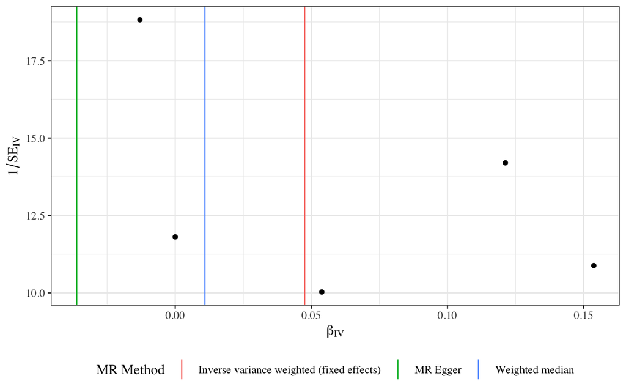

**Table 5:** Heterogenity tests for HV and HDL Cholesterol

| exposure | outcome | method | Q | Q_df | Q_pval |
| --- | --- | --- | --- | --- | --- |
| HV | hdl | MR Egger | 2.842623 | 3 | 0.4165315 |
| HV | hdl | Inverse variance weighted | 4.048508 | 4 | 0.3994809 |

**Table 6:** Test for directional pleitropy for HV and HDL Cholesterol

| id.exposure | id.outcome | outcome | exposure | egger_intercept | se | pval |
| --- | --- | --- | --- | --- | --- | --- |
| lqCA0d | eVpwfy | hdl | HV | 0.00672844 | 0.006127191 | 0.3523827 |

## MR analysis results

| exposure | outcome | method | nsnp | b | se | pval | Signif |
| --- | --- | --- | --- | --- | --- | --- | --- |
| LOAD | hdl | IVW | 16 | -0.02076389 | 0.008331200 | 1.269170e-02 | * |
| LOAD | hdl | Weighted median | 16 | -0.02569316 | 0.012650771 | 4.225945e-02 | * |
| LOAD | hdl | MR Egger | 16 | -0.03248492 | 0.030532722 | 3.053641e-01 |  |
| AAOS | hdl | IVW | 11 | -0.09873474 | 0.006307113 | 3.095022e-55 | *** |
| AAOS | hdl | Weighted median | 11 | -0.10046649 | 0.008737315 | 1.341435e-30 | *** |
| AAOS | hdl | MR Egger | 11 | -0.10946451 | 0.016433285 | 9.255071e-05 | *** |
| HV | hdl | IVW | 5 | 0.04755826 | 0.033071615 | 1.504231e-01 |  |
| HV | hdl | Weighted median | 5 | 0.01090758 | 0.042336420 | 7.966844e-01 |  |
| HV | hdl | MR Egger | 5 | -0.03616469 | 0.083105367 | 6.928470e-01 |  |